# R Notebook

```r
# Loading packages
library(ggplot2)
library(rstanarm)
```

# 10.1

Regression with interactions: Simulate 100 data points from the model, $y = b_0 + b_1 \cdot x + b_2 \cdot z + b_3 \cdot x \cdot z + error$ , with a continuous predictor $x$ and a binary predictor $z$, coefficients $b = (1, 2, -1, -2)$, and errors drawn independently from a normal distribution with mean 0 and standard deviation 3, as follows. For each data point i, first draw $z_i$, equally likely to take on the values 0 and 1. Then draw $x_i$ from a normal distribution with mean $z_i$ and standard deviation 1. Then draw the error from its normal distribution and compute $y_i$.

```r
set.seed(0)
# Simulating the data

# Number of data points
n <- 100
b <- c(1,2,-1,-2)
error_sd <- 3

# Create empty vectors to store simulated data
x <- c()
z <- c()
y <- c()

for (i in 1:n) {

  # Draw z with equal probability of 0 or 1
  z[i] <- rbinom(1, 1, .5)
  x[i] <- rnorm(1, mean = z[i], sd = 1)

  # Draw error from a normal distribution with mean 0 and standard deviation 3
  error <- rnorm(1, mean = 0, sd = error_sd)

  # Compute y using the given model
  y[i] <- b[1] + b[2] * x[i] + b[3] * z[i] + b[4] * x[i] * z[i] + error
}

# Display the simulated data
simulated_data <- data.frame(x = x, z = z, y = y)
simulated_data
```

| x | z | y |
| --- | --- | --- |
| 0.37354619 | 1 | 0.550929973 |
| 1.27242932 | 0 | 4.788782946 |
| -0.82046838 | 0 | 0.821350389 |
| 0.99423283 | 1 | 7.213960167 |
| 2.51178117 | 1 | 1.169529709 |
| -0.28946157 | 0 | -0.476568501 |
| -0.04493361 | 0 | 0.861561993 |
| 1.43568330 | 1 | -3.712615266 |
| 0.91897737 | 0 | 5.184363645 |
| 1.80418951 | 1 | -0.171320323 |

[output cut: 90 more lines]

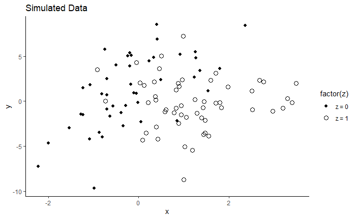

```r
# Create the scatter plot using ggplot2
ggplot(simulated_data, aes(x = x, y = y, shape = factor(z))) +
  geom_point(size = 3) +
  scale_shape_manual(values = c(20, 1), labels = c("z = 0", "z = 1")) +
  labs(title = "Simulated Data", x = "x", y = "y") +
  theme_classic()
```

2. Fit a regression predicting y from x and z with no interaction. Make a graph with the data and two parallel lines showing the fitted model.

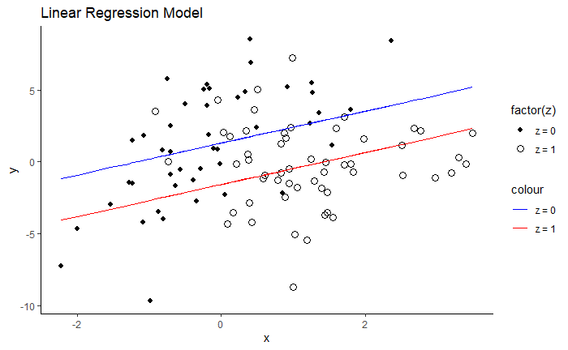

```r
# Fit linear regression model
model <- lm(y ~ x + z, data = simulated_data)

# Extract coefficients
b <- coef(model)

# Compute predicted y values for z = 0 and z = 1
y_pred_z0 <- b[1] + b[2] * x + b[3] * 0
y_pred_z1 <- b[1] + b[2] * x + b[3] * 1

# Create the scatter plot using ggplot2
ggplot(simulated_data, aes(x = x, y = y, shape = factor(z))) +
  geom_point(size = 3) +
  geom_line(aes(x = x, y = y_pred_z0, color = "blue")) +
  geom_line(aes(x = x, y = y_pred_z1, color = "red")) +
  scale_shape_manual(values = c(20, 1), labels = c("z = 0", "z = 1")) +
  scale_color_manual(values = c("blue", "red"), labels = c("z = 0", "z = 1")) +
  labs(title = "Linear Regression Model", x = "x", y = "y") +
  theme_classic()
```

3. Fit a regression predicting $y$ from $x$, $z$ and their interaction. Make a graph with the data and the two lines showing the fitted model.

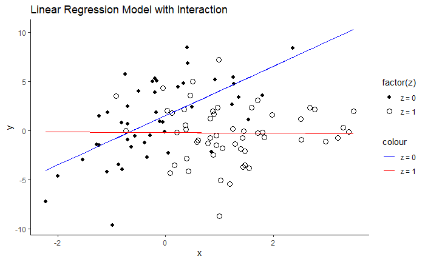

```r
# Add interaction term to simulated data
simulated_data$xz <- simulated_data$x * simulated_data$z

# Fit linear regression model with interaction term
model <- lm(y ~ x + z + xz, data = simulated_data)

# Extract coefficients
b <- coef(model)

# Compute predicted y values for z = 0 and z = 1
y_pred_z0 <- b[1] + b[2] * x + b[3] * 0 + b[4] * x * 0
y_pred_z1 <- b[1] + b[2] * x + b[3] * 1 + b[4] * x * 1

# Create the scatter plot using ggplot2
ggplot(simulated_data, aes(x = x, y = y, shape = factor(z))) +
  geom_point(size = 3) +
  geom_line(aes(x = x, y = y_pred_z0, color = "blue")) +
  geom_line(aes(x = x, y = y_pred_z1, color = "red")) +
  scale_shape_manual(values = c(20, 1), labels = c("z = 0", "z = 1")) +
  scale_color_manual(values = c("blue", "red"), labels = c("z = 0", "z = 1")) +
  labs(title = "Linear Regression Model with Interaction", x = "x", y = "y") +
  theme_classic()
```

# 10.2

We are given the output of a linear regression with an outcome $y$, a pre-treatment predictor $x$ and a treatment indicator $z$ as well as their interaction.

1. Write the equation of the estimated regression line of y on x for the treatment group, and the equation of the estimated regression line of y on x for the control group.

Solution: We know linear regression with two predictors and their interaction has the general form

$$y = 3.9 + 2.3 \cdot x$$
b) Just use R to graph this exercise. Graph the two regression lines, assuming the values of x fall in the range (0, 10). On this graph also include a scatterplot of data (using open circles for treated units and dots for controls) that are consistent with the fitted model.

Solution:

```r
intercepts = c(1.2,3.9)
slopes = c(1.6,2.3)
sigma = .5
n <- 100
x <- runif(n, min = 0, max = 10)
z <- rbinom(n, 1, .5)
err <- rnorm(n, mean = 0, sd = sigma)
y <- 1.2 + 1.6*x + 2.7*z + 0.7*x*z + err
data = data.frame(x,y,z)
```

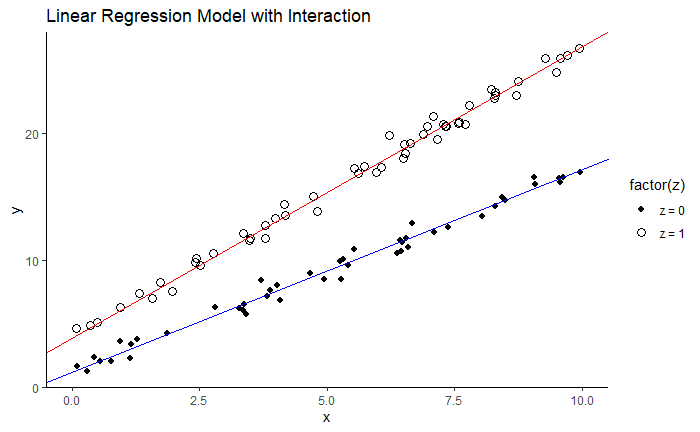

```r
ggplot(data, aes(x = x, y = y, shape = factor(z))) + xlim(0,10) +
  geom_point(size = 3) +
  geom_abline(intercept = intercepts[1], slope = slopes[1], colour = 'blue') +
  geom_abline(intercept = intercepts[2], slope = slopes[2], colour = 'red') +
  scale_shape_manual(values = c(20, 1), labels = c("z = 0", "z = 1")) +
  scale_color_manual(values = c("blue", "red"), labels = c("z = 0", "z = 1")) +
  labs(title = "Linear Regression Model with Interaction", x = "x", y = "y") +
  theme_classic()
```

```r
set.seed(0)
var1 <- rnorm(1000, 0, 1)
var2 <- rnorm(1000, 0, 1)

# Regression of var1 on var2
summary(lm(var1 ~ var2))
```

[output not shown]

# 10.4

Continuing the previous exercise, run a simulation repeating this process 100 times. This can be done using a loop. From each simulation, save the z-score (the estimated coefficient of var1 divided by its standard error). If the absolute value of the z-score exceeds 2, the estimate is “statistically significant.

How many of these 100 z-scores exceed 2 in absolute value, thus achieving the conventional level of statistical significance?

Solution:

```r
set.seed(0)
z_scores <- rep(NA, 100)
for (k in 1:100) {
var1 <- rnorm(1000, 0, 1)
var2 <- rnorm(1000, 0, 1)
fake <- data.frame(var1, var2)
fit <- stan_glm(var2 ~ var1, data=fake)
z_scores[k] <- coef(fit)[2] / se(fit)[2]
}
```

```r
sum(abs(z_scores) > 2)
```

[output not shown]